# Eksempler på visualiseringer

pmd

Indlæs de nødvendige biblioteket

```r
library(tidyverse)
library(here)
library(ndjson)
library(xslt)
library(fs)
library(ggplot2)
library(readxl)
library(tidytext)

require(readr)  # for read_csv()
require(purrr)  # for map(), reduce()

source(here("src/p017-functions.R"))
```

# Indlæs data

## De konverterede skuespil

```r
read_plays_jsonl(here("test-data")) %>% select(filename, everything()) -> plays
```

```
Parsing error on line 230
```

## Indlæs Excelarket

```r
variants <- read_excel(here("Rolleliste.xlsx")) %>%
     unnest_tokens(variant, Alias, token = "regex", pattern = ", ") %>%
    mutate(
      Karakter = tolower(Karakter),
      variant = tolower(variant)
    )
```

Kombiner skuespil og Excelark

```r
plays %>%
  mutate(speaker = tolower(speaker)) %>%
  left_join(variants, by = c("filename"="Filnavn", "speaker"="variant")) %>%
  mutate(speaker = if_else(!is.na(Karakter), Karakter, speaker)) %>%
  distinct -> plays
```

# Nu tæller vi total antal ord sagt pr karakter pr stykke. Dernæst omregnet til procent af totale ord i stykket.

```r
# count words in "spoke"
(plays %>%
  # remove rows that are not dialogue and empty speakers
  filter(!is.na(spoke), speaker != "") %>%

  # select only the columns, that we are interested in
  select(speaker, title, year, spoke) %>%

  # add the number of spoken words
  mutate(n_spoken_words = str_count(spoke, '\\w+')) %>%
  # remove the spoken words
  select(-spoke) %>%

  # group by title and speaker
  group_by(title, year, speaker) %>%

  # Sum the words spoken by each speaker in each play
  # Lastly store the new data frame in a new reference for later use
  summarise(words = sum(n_spoken_words), title, year) %>%
    distinct() -> my_summary
)
   # Calculate %
(my_summary %>%
    ungroup(speaker) %>%
    summarise(words_play = sum(words)) -> totals)

(my_summary %>%
  full_join(totals) %>%
  summarise(freq = words / words_play, speaker, title, year, words, words_play) ->
    new_summary
    )
  # Sort by freq
(new_summary %>%
  arrange(desc(freq)))
```

[output not shown]

# Visualisering

```r
character_plot <- function(character_name) {
  new_summary %>%
  filter(speaker == character_name) %>%
  arrange(year) %>%
  ggplot(aes(fill = title, y = freq, x = title)) +
    geom_bar(stat="identity") +
    theme(legend.position="bottom") +
    labs(
      title = "Procent talte ord over år og komedier",
      subtitle = toupper(character_name),
      caption = "Kilde: DSL"
    ) +
  xlab("year") +
  ylab("Procent sagte ord") +
  facet_wrap(~year, ncol=nrow(new_summary), switch="x") +
  theme(axis.text.x=element_blank())
}
```

Basalt set skal vi have implementeret en funktion á la `character_comparison_plot(<list of character names>, <list of character names>)`.

```r
# count words in "spoke"
plays %>%
  # remove rows that are not dialogue and empty speakers
  filter(!is.na(spoke), speaker != "") %>%

  # select only the columns, that we are interested in
  select(speaker, title, year, spoke) %>%

  # add the number of spoken words
  mutate(n_spoken_words = str_count(spoke, '\\w+')) %>%
  # remove the spoken words
  select(-spoke) %>%

  # group by title and speaker
  group_by(title, year, speaker) %>%

  # Sum the words spoken by each speaker in each play
  # Lastly store the new data frame in a new reference for later use
  summarise(words = sum(n_spoken_words), title, year) %>%
  distinct() -> summary
summary %>%
    ungroup(speaker) %>%
    summarise(words_play = sum(words)) -> totals
summary %>%
  full_join(totals) %>%
  summarise(freq = words / words_play, speaker, title, year, words, words_play) -> summary
```

## Sammenligning af enkelte karakterer

```
'switch' is deprecated.
Use 'strip.position' instead.
See help("Deprecated")
```

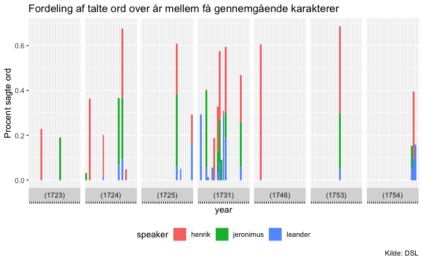

```r
  summary %>%
  #filter(speaker %in% c("henrik","pernille","troels")) %>%
filter(speaker %in%   c("henrik", "jeronimus", "leander")) %>%
  arrange(year) %>%
  ggplot(aes(fill = speaker, y = freq, x = title)) +
    geom_bar(stat="identity") +
    theme(legend.position="bottom") +
    labs(
      title = "Fordeling af talte ord over år mellem få gennemgående karakterer",
      #subtitle = toupper("TEST"),
      caption = "Kilde: DSL"
    ) +
  xlab("year") +
  ylab("Procent sagte ord") +
  facet_wrap(~year, ncol=nrow(summary), switch="x") +
  theme(axis.text.x=element_blank())
```

## Sammenligning af grupper af karakterer

```
'switch' is deprecated.
Use 'strip.position' instead.
See help("Deprecated")
```

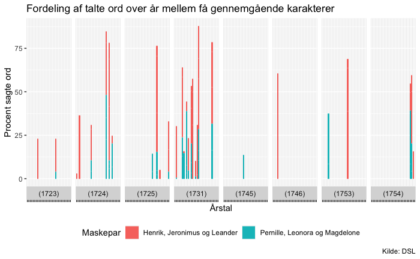

```r
group_1 <- c("henrik", "jeronimus", "leander")
group_2 <- c("pernille", "leonora", "magdelone")

summary %>%
  filter(speaker %in% c(group_1, group_2)) %>%
  mutate(gruppe = if_else(speaker %in% group_1, "Henrik, Jeronimus og Leander","Pernille, Leonora og Magdelone")) %>%
  #filter(speaker %in% c("henrik","pernille","leonora")) %>%
  arrange(year) %>%
  ggplot(aes(fill = gruppe, y = freq*100, x = title)) +
    geom_bar(stat="identity") +
    theme(legend.position="bottom") +
    labs(
      title = "Fordeling af talte ord over år mellem få gennemgående karakterer",
      #subtitle = toupper("TEST"),
      caption = "Kilde: DSL"
    ) +
  xlab("Årstal") +
  ylab("Procent sagte ord") +
  labs(fill='Maskepar') +
  facet_wrap(~year, ncol=nrow(summary), switch="x") +
  theme(axis.text.x=element_blank())
```

## Vende 90° grader

```
'switch' is deprecated.
Use 'strip.position' instead.
See help("Deprecated")
```

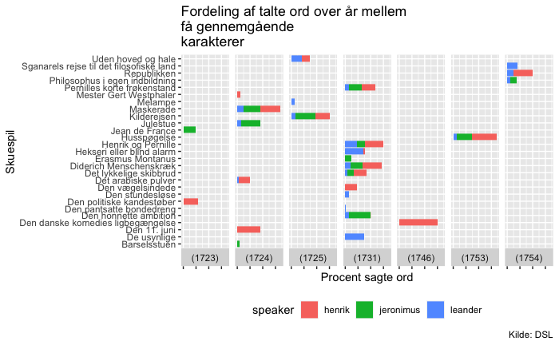

```r
summary %>%
  #filter(speaker %in% c("henrik","pernille","troels")) %>%
  filter(speaker %in%   c("henrik", "jeronimus", "leander")) %>%
  arrange(year) %>%
  ggplot(aes(fill = speaker, y = freq, x = title)) +
    geom_bar(stat="identity") +
    theme(legend.position="bottom") +
    labs(
      title = "Fordeling af talte ord over år mellem \nfå gennemgående\nkarakterer",
      #subtitle = toupper("TEST"),
      caption = "Kilde: DSL"
    ) +
  xlab("Skuespil") +
  ylab("Procent sagte ord") +
  facet_wrap(~year, ncol=nrow(summary), switch="x") +
  theme(axis.text.x=element_blank()) +
  coord_flip()
```

## Et trick til at få stykkerne til at stå i årsrække

Indenfor statistik arbejder man med noget, som på engelsk hedder *factor*. Jeg mener, at det på dansk hedder faktor. Det er når man har en variabel eller observation, som kan tage værdier, der ikke er sorterbare i sog selv. Fx en farve. Her kan man så selv angive værdiernes rækkefølge.

Dette kan vi udnytte til sortering af titel. Jeg laver først en liste med alle de anvendte titler og sorterer den efter årstallet. Derefter omformer jeg titel kolonnen til en faktorvariabel og angiver der den rækkefølge som jeg fik fra sorteringen efter årstal.

```r
summary %>%
  filter(speaker %in%   c("henrik", "jeronimus", "leander")) %>%
  #mutate(title = str_c(title, " ", year)) %>%
  distinct(title) %>%
  arrange(year) %>%
  pull(title) -> factor_levels

factor_levels
```

```
 [1] Den politiske kandestøber                Jean de France
 [3] Barselsstuen                             Den 11. juni
 [5] Det arabiske pulver                      Julestue
 [7] Maskerade                                Mester Gert Westphaler
 [9] Kilderejsen                              Melampe
[11] Uden hoved og hale                       De usynlige
[13] Den honnette ambition                    Den pantsatte bondedreng
[15] Den stundesløse                          Den vægelsindede
[17] Det lykkelige skibbrud                   Diderich Menschenskræk
[19] Erasmus Montanus                         Hekseri eller blind alarm
[21] Henrik og Pernille                       Pernilles korte frøkenstand
[23] Den danske komedies ligbegængelse        Husspøgelse
[25] Philosophus i egen indbildning           Republikken
[27] Sganarels rejse til det filosofiske land
27 Levels: Den politiske kandestøber Jean de France Barselsstuen ... Sganarels rejse til det filosofiske land
```

```r
summary$title_fct <- factor(summary$title, factor_levels)
```

Herefter sorterer titlerne sig fint

```
'switch' is deprecated.
Use 'strip.position' instead.
See help("Deprecated")
```

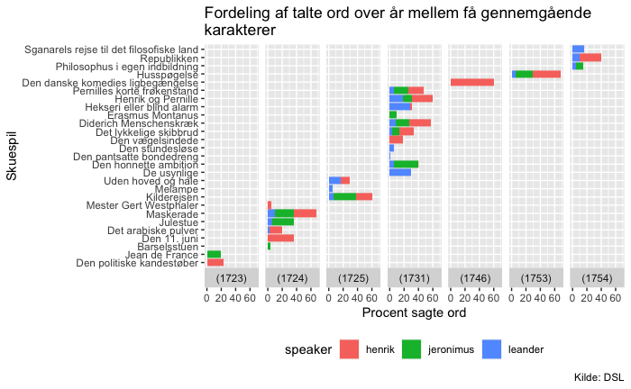

```r
summary %>%
  #filter(speaker %in% c("henrik","pernille","troels")) %>%
  filter(speaker %in%   c("henrik", "jeronimus", "leander")) %>%
  #arrange(year) %>%
  #mutate(title = str_c(title," ",year)) %>%
  ggplot(aes(fill = speaker, y = 100*freq, x = title_fct)) +
    geom_bar(stat="identity") +
    theme(legend.position="bottom") +
    labs(
      title = "Fordeling af talte ord over år mellem få gennemgående\nkarakterer",
      #subtitle = toupper("TEST"),
      caption = "Kilde: DSL"
    ) +
  xlab("Skuespil") +
  ylab("Procent sagte ord") +
  facet_wrap(~year, ncol=nrow(summary), switch="x") +
  #theme(axis.text.x=element_blank()) +
  coord_flip()
```

## diagram uden opdeling på årstal

```r
summary_fct2 %>% select(title_fct2)
```

| title | year | title_fct2 |
| --- | --- | --- |
| Barselsstuen | (1724) | NA |
| Barselsstuen | (1724) | NA |
| Barselsstuen | (1724) | NA |
| Barselsstuen | (1724) | NA |
| Barselsstuen | (1724) | NA |
| Barselsstuen | (1724) | NA |
| Barselsstuen | (1724) | NA |
| Barselsstuen | (1724) | NA |
| Barselsstuen | (1724) | NA |
| Barselsstuen | (1724) | NA |

[output cut: 578 more lines]

[figure not shown]

```r
summary_fct2 %>%
  #filter(speaker %in% c("henrik","pernille","troels")) %>%
  filter(speaker %in%   c("henrik", "jeronimus", "leander")) %>%
  ggplot(aes(fill = speaker, y = 100*freq, x = title_fct2)) +
    geom_bar(stat="identity") +
    theme(legend.position="bottom") +
    labs(
      title = "Fordeling af talte ord over år mellem få gennemgående\nkarakterer",
      #subtitle = toupper("TEST"),
      caption = "Kilde: DSL"
    ) +
  xlab("Skuespil") +
  ylab("Procent sagte ord") +
  #facet_wrap(~year, ncol=nrow(summary), switch="x") +
  #theme(axis.text.x=element_blank()) +
  coord_flip()
```

## Let’s Go Crazy

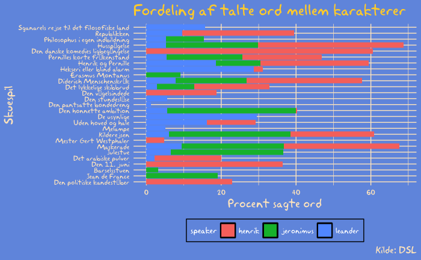

```r
summary %>%
  #filter(speaker %in% c("henrik","pernille","troels")) %>%
  filter(speaker %in%   c("henrik", "jeronimus", "leander")) %>%
  arrange(year) %>%
  ggplot(aes(fill = speaker, y = 100*freq, x = title)) +
    geom_bar(stat="identity") +
    theme_simpsons(
      title.font = "Akbar",
      text.font = "Akbar",
      axis.text.size = 8) +
    theme(legend.position="bottom") +
    labs(
      title = "Fordeling af talte ord mellem karakterer",
      #subtitle = toupper("TEST"),
      caption = "Kilde: DSL"
    ) +
  xlab("Skuespil") +
  ylab("Procent sagte ord") +
  #facet_wrap(~year, ncol=nrow(summary), switch="x") +
  #theme(axis.text.x=element_blank()) +
  coord_flip()
```

## Mere anvendelige eksempler

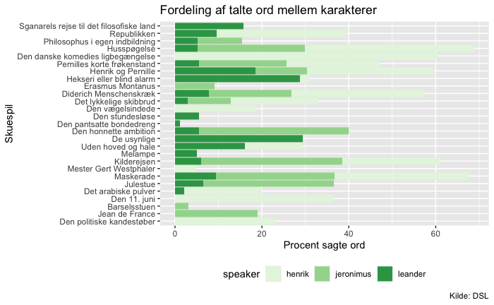

```r
summary %>%
  #filter(speaker %in% c("henrik","pernille","troels")) %>%
  filter(speaker %in%   c("henrik", "jeronimus", "leander")) %>%
  arrange(year) %>%
  ggplot(aes(fill = speaker, y = 100*freq, x = title)) +
    geom_bar(stat="identity") +
    theme(legend.position="bottom") +
    labs(
      title = "Fordeling af talte ord mellem karakterer",
      #subtitle = toupper("TEST"),
      caption = "Kilde: DSL"
    ) +
  xlab("Skuespil") +
  ylab("Procent sagte ord") +
  scale_fill_brewer(palette = "Greens") -> p # VÆLG GRØN PALETTE

p + coord_flip()
```

```
'switch' is deprecated.
Use 'strip.position' instead.
See help("Deprecated")
```

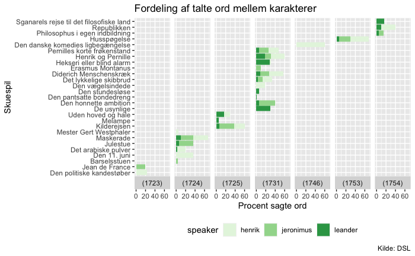

```r
p +
  facet_wrap(~year, ncol=nrow(summary), switch="x") +
  coord_flip()
```

## Viridis

```r
library("viridis")
```

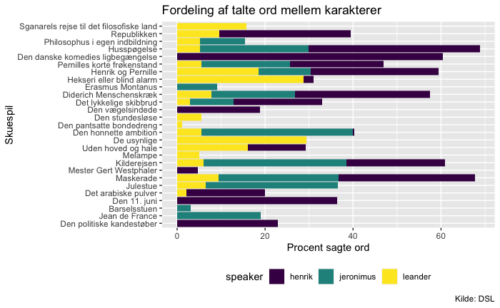

```r
summary %>%
  #filter(speaker %in% c("henrik","pernille","troels")) %>%
  filter(speaker %in%   c("henrik", "jeronimus", "leander")) %>%
  arrange(year) %>%
  ggplot(aes(fill = speaker, y = 100*freq, x = title)) +
    geom_bar(stat="identity") +
    theme(legend.position="bottom") +
    labs(
      title = "Fordeling af talte ord mellem karakterer",
      #subtitle = toupper("TEST"),
      caption = "Kilde: DSL"
    ) +
  xlab("Skuespil") +
  ylab("Procent sagte ord") +
  scale_fill_viridis(discrete = TRUE) +
  coord_flip() -> p

p
```

```
'switch' is deprecated.
Use 'strip.position' instead.
See help("Deprecated")
```

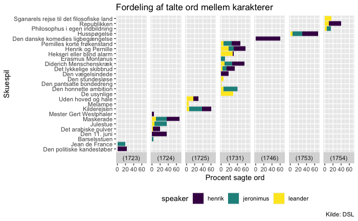

```r
p + facet_wrap(~year, ncol=nrow(summary), switch="x")
```

## Economist

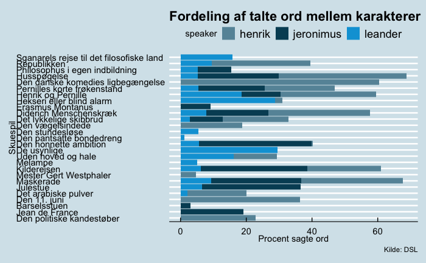

```r
summary %>%
  #filter(speaker %in% c("henrik","pernille","troels")) %>%
  filter(speaker %in%   c("henrik", "jeronimus", "leander")) %>%
  arrange(year) %>%
  ggplot(aes(fill = speaker, y = 100*freq, x = title)) +
    geom_bar(stat="identity") +
    theme(legend.position="bottom") +
    labs(
      title = "Fordeling af talte ord mellem karakterer",
      #subtitle = toupper("TEST"),
      caption = "Kilde: DSL"
    ) +
  xlab("Skuespil") +
  ylab("Procent sagte ord") +
  #scale_fill_brewer(palette = "Greens") +
  theme_economist() + scale_fill_economist() +
  coord_flip() -> p

p
```

```
'switch' is deprecated.
Use 'strip.position' instead.
See help("Deprecated")
```

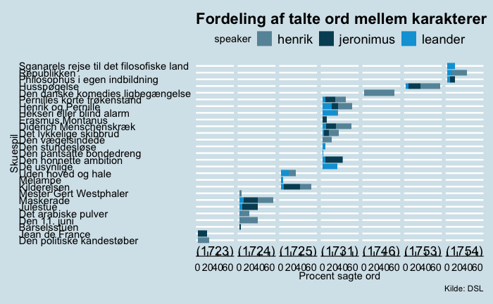

```r
p + facet_wrap(~year, ncol=nrow(summary), switch="x")
```

```r
NA
```

## Minimal

```
'switch' is deprecated.
Use 'strip.position' instead.
See help("Deprecated")
```

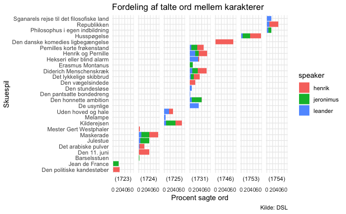

```r
summary %>%
  #filter(speaker %in% c("henrik","pernille","troels")) %>%
  filter(speaker %in%   c("henrik", "jeronimus", "leander")) %>%
  arrange(year) %>%
  ggplot(aes(fill = speaker, y = 100*freq, x = title)) +
    geom_bar(stat="identity") +
    theme(legend.position="bottom") +
    labs(
      title = "Fordeling af talte ord mellem karakterer",
      #subtitle = toupper("TEST"),
      caption = "Kilde: DSL"
    ) +
  xlab("Skuespil") +
  ylab("Procent sagte ord") +
  #scale_fill_brewer(palette = "Greens") +
  facet_wrap(~year, ncol=nrow(summary), switch="x") +
  #theme(axis.text.x=element_blank()) +
  coord_flip() +
  #theme_bw()
  theme_minimal()
```

## Gruppesammenligning igen

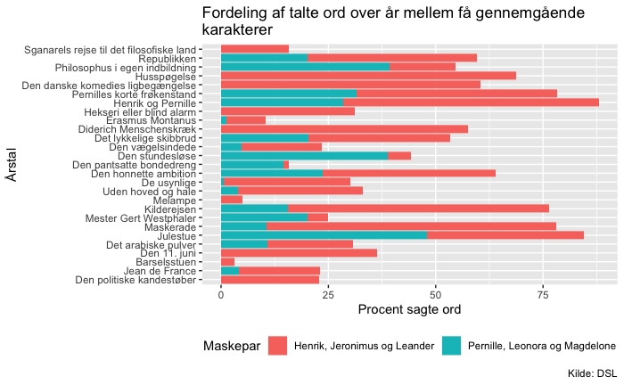

```r
group_1 <- c("henrik", "jeronimus", "leander")
group_1_name <- "Henrik, Jeronimus og Leander"

group_2 <- c("pernille", "leonora", "magdelone")
group_2_name <- "Pernille, Leonora og Magdelone"

summary %>%
  filter(!is.na(title)) %>%
  filter(speaker %in% c(group_1, group_2)) %>%
  mutate(gruppe = if_else(speaker %in% group_1, group_1_name,group_2_name)) %>%
  ggplot(aes(fill = gruppe, y = freq*100, x = title)) +
    geom_bar(stat="identity") +
    theme(legend.position="bottom") +
    labs(
      title = "Fordeling af talte ord over år mellem få gennemgående\nkarakterer",
      #subtitle = toupper("TEST"),
      caption = "Kilde: DSL"
    ) +
  xlab("Årstal") +
  ylab("Procent sagte ord") +
  labs(fill='Maskepar') +
  coord_flip()
```

# Gemme en visualisering som liggende A4 PDF

```r
ggsave(filename="hjl-række-uden-facet.pdf",
       width = 297,
       height = 210,
       units = "mm")
```